# MAMBO Tutorial

This is a tutorial for running metabarcoding data sets through MAMBO (Metabarcoding Analysis of Modeled Bayesian Occurrences). You should start with two ASV tables, each of which has columns as samples and rows as ASVs.

```r
library(mambo)
```

## ASV Tables

ASV count tables should be loaded as R data frames or matrices. The values in the tables represent the occurrence (number of reads) for each ASV (rows) in each sample (columns). The table should have both row and column names uniquely identifying ASVs and samples.

We supply two sets of two example ASV count tables in `mambo`: 16S and 18S data from the California Current Ecosystem (‘`counts.16s`’ and ‘`counts.18s`’), and 12S and COI data from Blackman (‘`counts.12s`’ and ‘`counts.COI`’).

```r
counts.16s[1:8, 1:4]
```

```
      CN18Fc43_5_eDNA CN18FESPkoa_SC58 CN18FESPkoa_SC43 CN18FESPkoa_SC40
ASV_1            2830             3158             2985             3624
ASV_2            8609             8452            10441            11390
ASV_3            2302             1954             2657             3248
ASV_4              54               76               88              105
ASV_5             405              460              523              600
ASV_6             827             1014             1217             1271
ASV_7             206              194              280              309
ASV_8             842              758              846             1166
```

We also supply metadata for the CCE samples as `sample.meta`:

```r
str(sample.meta)
```

```
'data.frame':   131 obs. of  46 variables:
 $ sample               : chr  "Lasker18Sc124_17" "Lasker18Sc124_19" "Lasker18Sc124_3" "Lasker18Sc124_5" ...
 $ Dataset              : chr  "Merged2018" "Merged2018" "Merged2018" "Merged2018" ...
 $ project_name         : chr  "eCruises_2018" "eCruises_2018" "eCruises_2018" "eCruises_2018" ...
 $ vessel               : chr  "Lasker" "Lasker" "Lasker" "Lasker" ...
 $ ESP_sample_match     : chr  "Lasker18Sc124_17_D0078" "Lasker18Sc124_19_D0079" "Lasker18Sc124_3_D0073" "Lasker18Sc124_5_D0074" ...
 $ year                 : int  2018 2018 2018 2018 2018 2018 2018 2018 2018 2018 ...
 $ season               : chr  "Spring" "Spring" "Spring" "Spring" ...
 $ collection_date_Flyer: int  20180604 20180604 20180604 20180604 20180605 20180605 20180605 20180606 20180606 20180606 ...
 $ sampling_platform    : chr  "Lasker" "Lasker" "Lasker" "Lasker" ...
 $ sampling_device      : chr  "CTD" "CTD" "CTD" "CTD" ...
 $ filtration_device    : chr  "peristaltic" "peristaltic" "peristaltic" "peristaltic" ...
 $ control_status       : chr  "Exp" "Exp" "Exp" "Exp" ...
 $ station              : chr  "401" "401" "401" "401" ...
 $ bottom_depth_m       : int  1678 1678 1678 1678 974 974 974 98 98 98 ...
```

[output cut: 32 more lines]

## Filter data

First we’ll extract the Lasker samples from the CCE 16S and 18S data and filter them using the default values. The `filterCountData()` function will report the number of ASVs and samples removed at each step.

```r
lasker.samples <- sample.meta$sample[sample.meta$cruise == 'Lasker']

lasker.16s <- filterCountData(counts.16s[, lasker.samples])
```

```
Input: 69 samples and 7077 ASVs.
```

```
0 samples removed due to insufficent ASVs per sample.
```

```
5574 ASVs removed due to insufficient samples per ASV.
```

```
0 samples removed due to low read counts.
```

```
5 ASVs removed due to low read counts across samples.
```

```
Retained: 69 samples and 1498 ASVs.
```

```r
lasker.18s <- filterCountData(counts.18s[, lasker.samples])
```

```
Input: 69 samples and 10475 ASVs.
```

```
0 samples removed due to insufficent ASVs per sample.
```

```
3602 ASVs removed due to insufficient samples per ASV.
```

```
0 samples removed due to low read counts.
```

```
686 ASVs removed due to low read counts across samples.
```

```
Retained: 69 samples and 6187 ASVs.
```

## Run MAMBO

To run the main function, `mambo()`, we need to supply labels for the response and predictor datasets and the response and predictor count tables, along with the number of replicates (`nrep`) and parameters for the Bayesian MCMC run (see `?mambo`). One can also specify a label for the run (‘`run.label`’) that will be used for the log and results file. By default, this is set to ‘`mambo`’.

```r
results <- mambo(
  resp.counts = lasker.18s,
  resp.label = 'Lasker_18S',
  pred.counts = lasker.16s,
  pred.label = 'Lasker_16S',
  nrep = 10,
  chains = 3,
  adapt = 100,
  burnin = 1000,
  run.label = 'Lasker'
)
```

To skip the Bayesian modeling and just compute diversity and run the PCAs, set `bayesian = FALSE`:

```r
results <- mambo(
  resp.counts = lasker.18s,
  resp.label = 'Lasker_18S',
  pred.counts = lasker.16s,
  pred.label = 'Lasker_16S',
  nrep = 10,
  bayesian = FALSE,
  label = 'Lasker'
)
```

While `mambo()` is running, it will output progress on the screen and to a log file named, ‘.YYYYMMDD_HHmmSS.log’. When the run is complete, it will write its results to an .RDS file in the working directory that is named the same as the log file, but ends in ‘.rds’. This file can be read into an R object using `readRDS()`:

```r
results <- readRDS('Lasker.Lasker.20260128_132951.rds')
```

## Examine model parameters and outputs

The output of `mambo()` is a list with five elements:

1. The filename of the .RDS file that was written:

```r
results$filename
```

```
[1] "Lasker.20260128_133912.rds"
```

2. The labels that were provided to the function for each locus:

```r
results$labels
```

```
         run         resp         pred
    "Lasker" "Lasker_18S" "Lasker_16S"
```

3. The MCMC parameters:

```r
results$params
```

```
         nrep        chains         adapt        burnin total.samples
           10             3           100          1000          1000
         thin
            1
```

4. The run times for the model:

```r
results$run.time
```

```
$start
[1] "2026-01-28 13:39:12 PST"

$end
[1] "2026-01-28 13:40:46 PST"

$elapsed
Time difference of 1.56117 mins
```

5. A list of the results for every replicate (`$reps`).

```r
length(results$reps)
```

```
[1] 10
```

Each element in the `$reps` list contains results for diversity and PCAs for each locus, and the Bayesian modelling for every replicate:

```r
names(results$reps[[1]])
```

```
[1] "total.diversity"  "sample.diversity" "pca"              "post.smry"
[5] "post.list"
```

The `$total.diversity` element is a vector giving the total ASV diversity for each locus:

```r
results$reps[[1]]$total.diversity
```

```
Lasker_18S Lasker_16S
  522.0967   151.6873
```

The `$sample.diversity` element is a data.frame giving the ASV diversity for each sample (rows) at each locus (columns):

```r
head(results$reps[[1]]$sample.diversity)
```

```
            sample Lasker_18S Lasker_16S
1 Lasker18Sc124_17  294.84529   66.52273
2 Lasker18Sc124_19  322.26063   62.52094
3  Lasker18Sc124_3  139.68020  109.13202
4  Lasker18Sc124_5  500.42628  113.88567
5 Lasker18Sc126_17   36.98184   56.25445
6  Lasker18Sc126_3   91.98398   78.88355
```

The `$pca` element contains PCA results for each locus, where `$rotation` has the loading values of ASVs on the PCs, `$x` has the scores for each sample on each PC, and `$importance` gives summary information on variance explained by each PC:

```r
str(results$reps[[1]]$pca[['Lasker_16S']])
```

```
List of 3
 $ rotation  : num [1:1498, 1:10] 0.0776 0.032 0.0136 -0.0417 -0.0572 ...
  ..- attr(*, "dimnames")=List of 2
  .. ..$ : chr [1:1498] "ASV_1" "ASV_2" "ASV_3" "ASV_4" ...
  .. ..$ : chr [1:10] "PC1" "PC2" "PC3" "PC4" ...
 $ x         : num [1:69, 1:10] -21.7 -20.8 44.5 37.5 -26.7 ...
  ..- attr(*, "dimnames")=List of 2
  .. ..$ : chr [1:69] "Lasker18Sc124_17" "Lasker18Sc124_19" "Lasker18Sc124_3" "Lasker18Sc124_5" ...
  .. ..$ : chr [1:10] "PC1" "PC2" "PC3" "PC4" ...
 $ importance: num [1:3, 1:10] 32.812 0.2172 0.2172 18.6435 0.0701 ...
  ..- attr(*, "dimnames")=List of 2
  .. ..$ : chr [1:3] "Standard deviation" "Proportion of Variance" "Cumulative Proportion"
  .. ..$ : chr [1:10] "PC1" "PC2" "PC3" "PC4" ...
 - attr(*, "class")= chr "summary.prcomp"
```

However, the function `extractPCA()`, will return this information for all replicates in a way that is easier to manipulate. It returns a list with one element for loadings, scores, and importance, where each is a data frame:

```r
pca <- extractPCA(results)
str(pca)
```

```
List of 3
 $ loadings  :'data.frame': 768500 obs. of  5 variables:
  ..$ asv    : chr [1:768500] "ASV_1" "ASV_2" "ASV_3" "ASV_4" ...
  ..$ pc     : num [1:768500] 1 1 1 1 1 1 1 1 1 1 ...
  ..$ rep    : num [1:768500] 1 1 1 1 1 1 1 1 1 1 ...
  ..$ loading: num [1:768500] -0.0284 0.0138 -0.0298 -0.0143 0.015 ...
  ..$ locus  : chr [1:768500] "Lasker_18S" "Lasker_18S" "Lasker_18S" "Lasker_18S" ...
 $ scores    :'data.frame': 13800 obs. of  5 variables:
  ..$ sample: chr [1:13800] "Lasker18Sc124_17" "Lasker18Sc124_19" "Lasker18Sc124_3" "Lasker18Sc124_5" ...
  ..$ pc    : num [1:13800] 1 1 1 1 1 1 1 1 1 1 ...
  ..$ rep   : num [1:13800] 1 1 1 1 1 1 1 1 1 1 ...
  ..$ score : num [1:13800] -11.7 -7.8 44.4 65.4 -59.1 ...
  ..$ locus : chr [1:13800] "Lasker_18S" "Lasker_18S" "Lasker_18S" "Lasker_18S" ...
 $ importance:'data.frame': 600 obs. of  5 variables:
  ..$ type : chr [1:600] "Standard deviation" "Proportion of Variance" "Cumulative Proportion" "Standard deviation" ...
  ..$ pc   : num [1:600] 1 1 1 2 2 2 3 3 3 4 ...
  ..$ rep  : num [1:600] 1 1 1 1 1 1 1 1 1 1 ...
  ..$ value: num [1:600] 56.8396 0.1957 0.1957 33.3372 0.0673 ...
  ..$ locus: chr [1:600] "Lasker_18S" "Lasker_18S" "Lasker_18S" "Lasker_18S" ...
```

If a Bayesian analysis was conducted, then the `$post.smry` element will be a matrix providing a summary of the posteriors from the Bayesian model for each parameter:

```r
head(results$reps[[1]]$post.smry)
```

```
                Lower95        Median    Upper95          Mean        SD
deviance     5560.97000 5662.58500000 5712.60000 5650.33228543 43.832023
intercept[1]   -3.36865   -0.04330110    3.20676   -0.03458025  1.673395
intercept[2]   -2.78326    0.08337180    2.71511    0.01785576  1.364568
intercept[3]   -3.99557   -0.00913374    4.06853   -0.06124661  2.049943
intercept[4]   -4.77789    0.03044220    5.29818    0.03126768  2.605600
intercept[5]   -3.83334    0.05584655    4.04631    0.06265087  1.991070
                      Mode      MCerr MC%ofSD SSeff       AC.10      psrf
deviance     5679.47822355 9.03256967    20.6    24  0.60086303 3.8651589
intercept[1]   -0.34464678 0.05134704     3.1  1062 -0.01278695 1.0014531
intercept[2]    0.34724766 0.04452299     3.3   939 -0.01371428 1.0172424
intercept[3]   -0.32495063 0.06159630     3.0  1108 -0.02748979 0.9993647
intercept[4]   -0.01192544 0.08231403     3.2  1002 -0.02166158 1.0004009
intercept[5]   -0.04495634 0.06202492     3.1  1030  0.03471186 1.0523479
```

… and `$post.list` will contain the actual posteior sample:

```r
str(results$reps[[1]]$post.list)
```

```
List of 5
 $ deviance : num [1:1002] 5706 5699 5718 5712 5709 ...
 $ intercept: num [1:10, 1:1002] 1.503 -0.401 0.367 -4.816 -5.352 ...
  ..- attr(*, "dimnames")=List of 2
  .. ..$ : chr [1:10] "Lasker_18S.PC1" "Lasker_18S.PC2" "Lasker_18S.PC3" "Lasker_18S.PC4" ...
  .. ..$ : chr [1:1002] "1101" "1102" "1103" "1104" ...
 $ b.prime  : num [1:10, 1:10, 1:1002] 1.71 0 0 0 0 ...
  ..- attr(*, "dimnames")=List of 3
  .. ..$ : chr [1:10] "Lasker_18S.PC1" "Lasker_18S.PC2" "Lasker_18S.PC3" "Lasker_18S.PC4" ...
  .. ..$ : chr [1:10] "Lasker_16S.PC1" "Lasker_16S.PC2" "Lasker_16S.PC3" "Lasker_16S.PC4" ...
  .. ..$ : chr [1:1002] "1101" "1102" "1103" "1104" ...
 $ w        : num [1:10, 1:10, 1:1002] 1 0 0 0 0 0 0 0 0 0 ...
  ..- attr(*, "dimnames")=List of 3
  .. ..$ : chr [1:10] "Lasker_18S.PC1" "Lasker_18S.PC2" "Lasker_18S.PC3" "Lasker_18S.PC4" ...
  .. ..$ : chr [1:10] "Lasker_16S.PC1" "Lasker_16S.PC2" "Lasker_16S.PC3" "Lasker_16S.PC4" ...
  .. ..$ : chr [1:1002] "1101" "1102" "1103" "1104" ...
 $ v        : num [1:10, 1:1002] 189 70.7 346.6 401.6 438.2 ...
  ..- attr(*, "dimnames")=List of 2
  .. ..$ : chr [1:10] "Lasker_18S.PC1" "Lasker_18S.PC2" "Lasker_18S.PC3" "Lasker_18S.PC4" ...
  .. ..$ : chr [1:1002] "1101" "1102" "1103" "1104" ...
```

If no Bayesian model was conducted, both of these will be `NULL`.

## Plot results

### Plot ASV diversity (the effective number of ASVs).

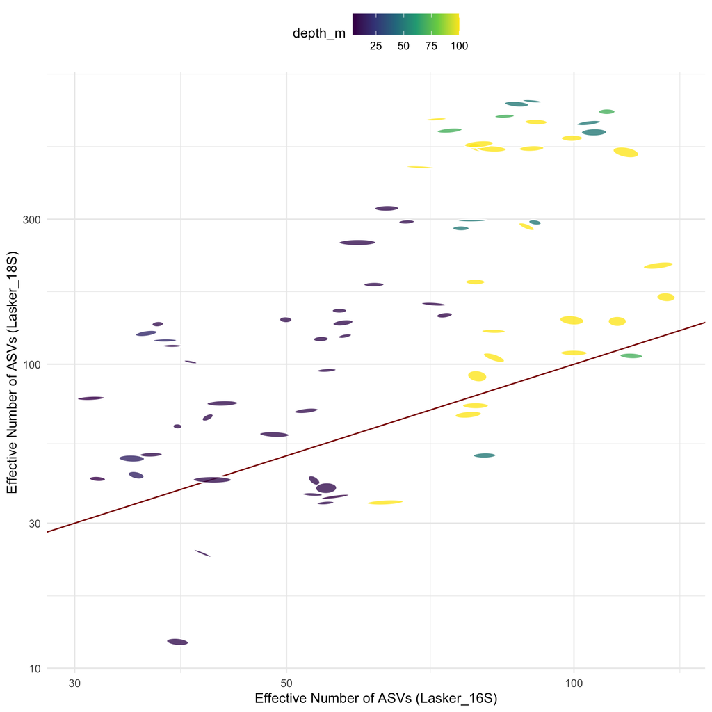

```r
plotDiversity(
  results,
  sample.df = sample.meta,
  ellipse.fill = 'depth_m'
)
```

This demonstrates how 18S diversity (y-axis) changes relative to 16S diversity (x-axis). The red line shows a 1:1 correspondence and ellipses show the 95-th percentile of the replicates in each axis. We have color-coded each ellipse relative to the depth that the sample was taken from to highlight a general pattern of increasing diversity with depth.

### Plot distribution of percent variance accounted for by each Principal Component

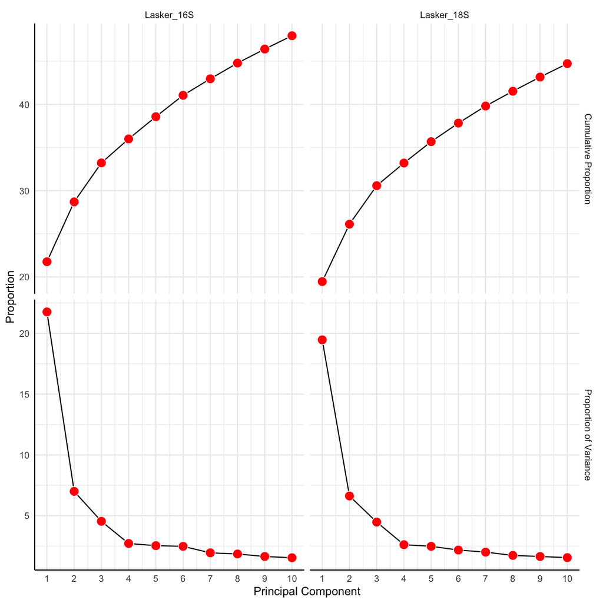

```r
screePlot(results)
```

### Biplot of selected Principal Components for a locus

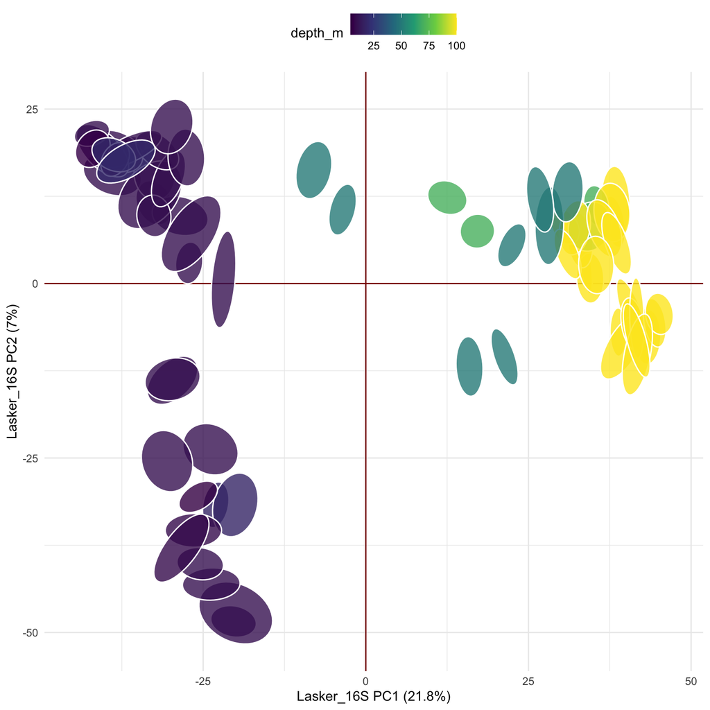

```r
plotPCs(
  results,
  locus.x = 'Lasker_16S',
  pc.x = 1,
  pc.y = 2,
  sample.df = sample.meta,
  ellipse.fill = 'depth_m'
)
```

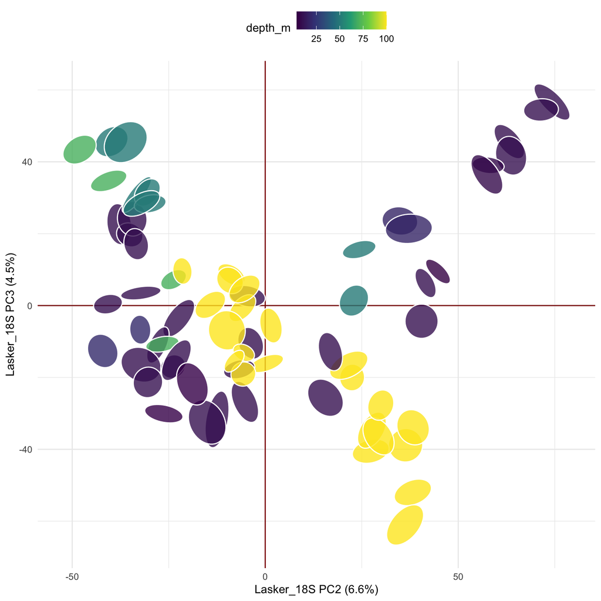

```r
plotPCs(
  results,
  locus.x = 'Lasker_18S',
  pc.x = 2,
  pc.y = 3,
  sample.df = sample.meta,
  ellipse.fill = 'depth_m'
)
```

## Summarize the posterior of predictive switches

Here we summarize the first four predictor and response PCs:

```r
sw.smry <- switchSummary(results, min.p = 0.9, resp.pcs = 1:4, pred.pcs = 1:4)
```

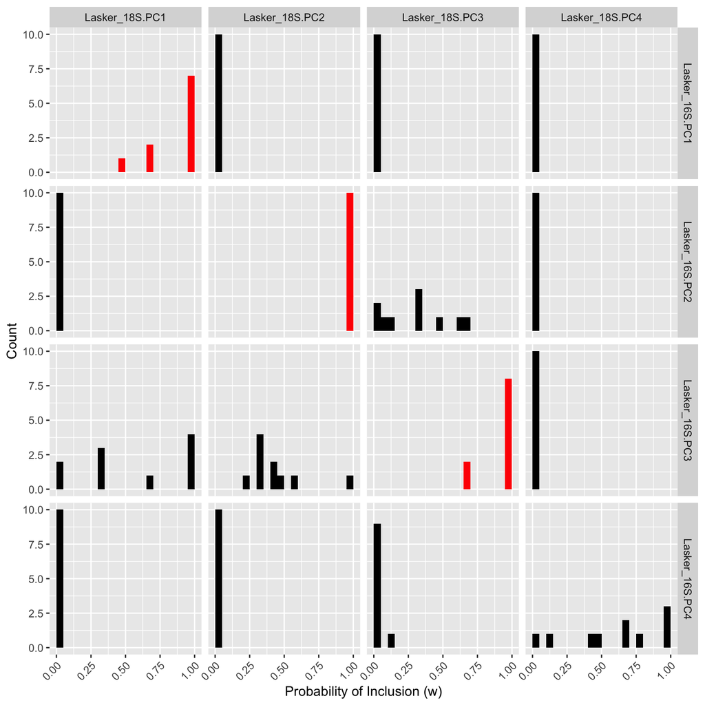

The `$smry` element is a data frame which identifies relationships between response and predictor PCS that were identified as significant based on the Bayesian model:

```r
sw.smry$smry
```

```
# A tibble: 3 × 3
  resp           pred           median.w
  <fct>          <fct>             <dbl>
1 Lasker_18S.PC1 Lasker_16S.PC1        1
2 Lasker_18S.PC2 Lasker_16S.PC2        1
3 Lasker_18S.PC3 Lasker_16S.PC3        1
```

We can plot those relationships using the `plotPCs()` function and supplying both the `x` and `y` loci and their respective PC numbers:

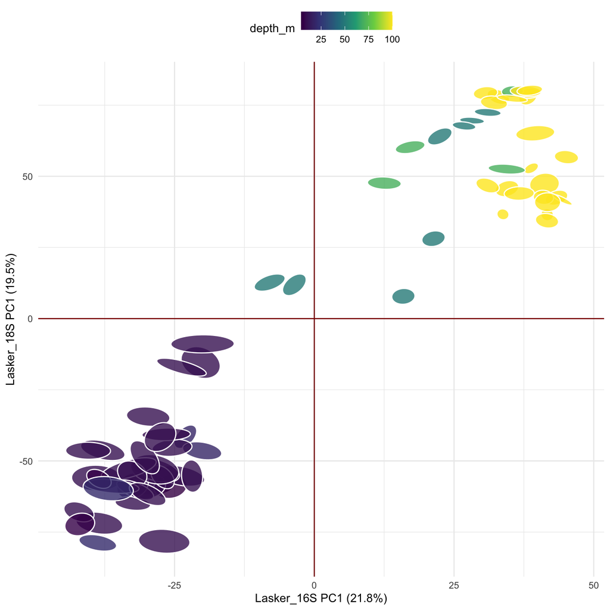

```r
plotPCs(
  results,
  locus.x = 'Lasker_16S',
  locus.y = 'Lasker_18S',
  pc.x = 1,
  pc.y = 1,
  sample.df = sample.meta,
  ellipse.fill = 'depth_m'
)
```

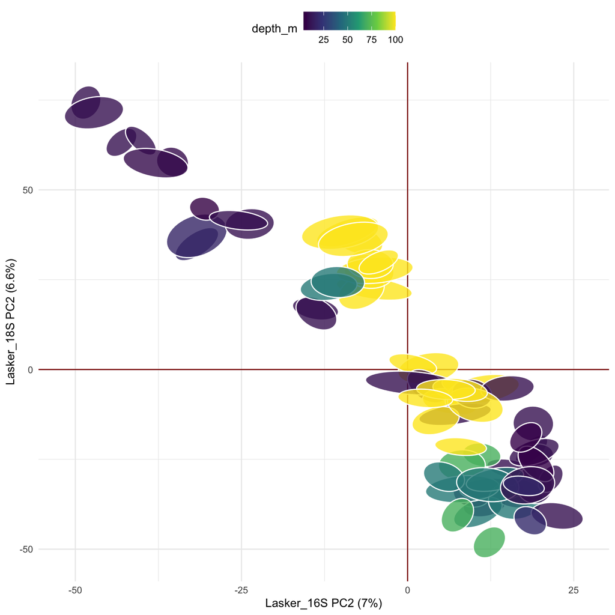

```r
plotPCs(
  results,
  locus.x = 'Lasker_16S',
  locus.y = 'Lasker_18S',
  pc.x = 2,
  pc.y = 2,
  sample.df = sample.meta,
  ellipse.fill = 'depth_m'
)
```

## Identify ASVs that have unusually high or low loadings.

Contrasts between these ‘outlier’ ASVs define the source of variation for that PC.

```r
outliers.16s.pc1 <- outlierLoadings(results, locus = 'Lasker_16S', pc = 1)

outliers.16s.pc1
```

```
# A tibble: 16 × 4
   asv     mean.loading median.loading pct.reps
   <chr>          <dbl>          <dbl>    <dbl>
 1 ASV_20        0.104          0.104         1
 2 ASV_64        0.0981         0.0981        1
 3 ASV_71        0.0972         0.0971        1
 4 ASV_37        0.0966         0.0966        1
 5 ASV_19        0.0934         0.0938        1
 6 ASV_89        0.0935         0.0935        1
 7 ASV_21        0.0938         0.0934        1
 8 ASV_110       0.0912         0.0907        1
 9 ASV_127       0.0897         0.0894        1
10 ASV_108       0.0899         0.0894        1
11 ASV_35        0.0907         0.0894        1
12 ASV_102       0.0901         0.0886        1
13 ASV_133       0.0885         0.0885        1
14 ASV_96        0.0864         0.0859        1
15 ASV_126       0.0865         0.0852        1
16 ASV_33       -0.0716        -0.0729        1
```

## Identify taxonomy of outlier ASVs

```r
# Add column name to match ASV tibble column name if it doesn't already
taxa.16s$asv <- rownames(taxa.16s)

# Merge the tibbles
asvs_out_16s_tax <- dplyr::left_join(outliers.16s.pc1, taxa.16s, by = "asv")

head(asvs_out_16s_tax)
```

```
# A tibble: 6 × 11
  asv    mean.loading median.loading pct.reps Kingdom  Phylum Class Order Family
  <chr>         <dbl>          <dbl>    <dbl> <chr>    <chr>  <chr> <chr> <chr>
1 ASV_20       0.104          0.104         1 Bacteria Prote… Alph… SAR1… Clade…
2 ASV_64       0.0981         0.0981        1 Bacteria Prote… Alph… SAR1… Clade…
3 ASV_71       0.0972         0.0971        1 Bacteria Prote… Alph… SAR1… Clade…
4 ASV_37       0.0966         0.0966        1 Bacteria Prote… Gamm… HOC36 HOC36
5 ASV_19       0.0934         0.0938        1 Bacteria Bacte… Bact… Flav… Flavo…
6 ASV_89       0.0935         0.0935        1 Bacteria Prote… Alph… SAR1… Clade…
# ℹ 2 more variables: Genus <chr>, Species <chr>
```